# Editorial

Abstract

“Editorial” published in R News.

I had the opportunity recently to examine the development of the R Project. A dramatic index of this development is the rapid growth in R packages, which is displayed in Figure 1; because the vertical axis in this graph is on a log scale, the least-squares linear-regression line represents exponential growth.

This issue of R News is another kind of testament to the richness and diversity of applications programmed in R: Hadley Wickham, Michael Lawrence, Duncan Temple Lang, and Deborah Swayne describe the **rggobi** package, which provides an interface to GGobi, software for dynamic and interactive statistical graphics. Carsten Dormann, Bernd Gruber, and Jochen Fründ introduce the **bipartite** package for examining interactions among species in ecological communities. Ioannis Kosmidis explains how to use the **profileModel** package to explore likelihood surfaces and construct confidence intervals for parameters of models fit by maximum-likelihood and closely related methods. Ingo Feinerer illustrates how the **tm** (“text-mining”) package is employed for the analysis of textual data. Yihui Xie and Xiaoyne Cheng demonstrate the construction of statistical animations in R with the **animation** package. Thomas Yee introduces the **VGAM** package, which is capable of fitting a dizzying array of statistical models. Paul Murrell shows how the **compare** package is used to locate similarities and differences among non-identical objects, and explains how the package may be applied to grading students’ assignments. Arthur Allignol, Jan Beyersmann, and Martin Schumacher describe the **mvna** package for the Nelson-Aalen estimator of cumulative transition hazards in multistate models. Finally, in the latest installment of the *Programmers’ Niche* column, Vince Carey reveals the mind-bending qualities of recursive computation in R without named self-reference.

The “news” portion of this issue of *R Rnews* includes a report on the recent *useR!* conference in Dortmund, Germany; announcements of *useR! 2009* in Rennes, France, and of *DSC 2009* in Copenhagen, Denmark, both to be held in July; news from the R Foundation and from the Bioconductor Project; the latest additions to CRAN; and changes in the recently released version 2.8.0 of R.

Unless we accumulate enough completed articles to justify a third issue in 2008, this will be my last issue as editor-in-chief of *R News*. Barring a third issue in 2008, this is also the last issue of *R News* — but don’t panic! *R News* will be reborn in 2009 as *The R Journal*. Moreover, the purpose and general character of the publication will be largely unchanged. We think that the new name better reflects the direction in which *R News* has evolved, and in particular the quality of the refereed articles that we publish.

During my tenure as an *R News* editor, I’ve had the pleasure of working with Vince Carey, Peter Dalgaard, Torsten Hothorn, and Paul Murrell. I look forward to working next year with Heather Turner, who is joining the editorial board in 2009, which will be my last year on the board.

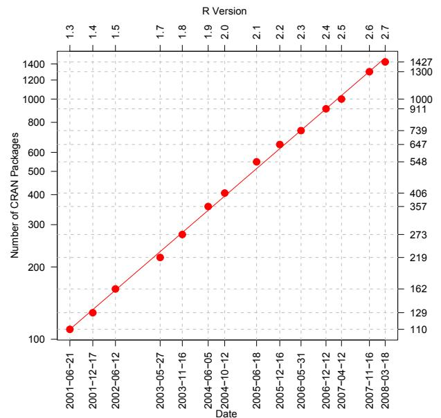

Figure 1: The number of R packages on CRAN has grown exponentially since R version 1.3 in 2001. Source of Data: https://svn.r-project.org/R/branches/ .